# index

### Practical Lab 3 - Vanilla CNN and Fine-Tune VGG16 - for Dogs and Cats Classification

| Student Name | Student ID |
| --- | --- |
| Haysam Elamin | 8953681 |

##### Understanding the Problem

**Objective:**

Build and evaluate deep learning models capable of accurately classifying images of dogs and cats. The goal is to explore both a custom neural network and a transfer learning approach (VGG16) to identify which performs better in terms of accuracy, precision, recall, and generalization. This can be extended to other animal image classification tasks and is foundational for real-world image recognition systems.

**Approach:**

We will work with a subset of the Dogs vs Cats dataset consisting of 5,000 labeled images. The project will include:

**Exploratory Data Analysis (EDA)**

Analyze the dataset through visualizations and statistics to understand the distribution and characteristics of the image data.

**Model Training**

Model 1: Train a custom Convolutional Neural Network (CNN).

Model 2: Fine-tune a VGG16 model pre-trained on ImageNet using transfer learning.

Model Evaluation Compare model performance using:

**Accuracy**

Confusion matrix

Precision, recall, F1-score

Precision-recall curve

```python
# Import necessary dependencies
import os
import pandas as pd
import numpy as np
import tensorflow as tf
from tensorflow.keras import layers, models, Input
from tensorflow.keras.applications import VGG16
from tensorflow.keras.applications.vgg16 import preprocess_input
from tensorflow.keras.optimizers import Adam
from tensorflow.keras.callbacks import EarlyStopping, ModelCheckpoint
from sklearn.model_selection import train_test_split
from sklearn.metrics import classification_report, confusion_matrix
import matplotlib.pyplot as plt
from PIL import Image
import random
from tensorflow.keras.models import load_model
from sklearn.metrics import precision_recall_curve, average_precision_score
from sklearn.metrics import accuracy_score
```

### 1. Load and Prepare Dataset

**Download the Dataset** Go to Kaggle’s Dogs vs Cats Dataset page (you’ll need a Kaggle account). Download train.zip, which contains 25,000 images, and manually extract 5,000 images (e.g., 2,500 dogs + 2,500 cats)

```python
# Set base path and number of images to use
data_dir = "data/train"
NUM_IMAGES = 5000  # we can change this later to use more or fewer images

# List and filter image files
all_filenames = os.listdir(data_dir)
image_files = [f for f in all_filenames if f.lower().endswith(('.jpg', '.jpeg', '.png'))]
random.seed(42)
random.shuffle(image_files)
image_files = image_files[:NUM_IMAGES]

# Create DataFrame and assign labels
df = pd.DataFrame(image_files, columns=['filename'])
df['label'] = df['filename'].apply(lambda x: 1 if 'dog' in x.lower() else 0)
df = df.sample(frac=1, random_state=42).reset_index(drop=True)

print("Image data loaded and labeled.")
print(f"Total image files used: {len(df)}")
print(df['label'].value_counts())
print(df.head())
```

```
Image data loaded and labeled.
Total image files used: 5000
label
1    2500
0    2500
Name: count, dtype: int64
        filename  label
0   dog.1216.jpg      1
1  cat.10555.jpg      0
2  dog.11401.jpg      1
3  cat.10964.jpg      0
4  cat.11484.jpg      0
```

### 2- Show Image from Dataset by Changing a Variable

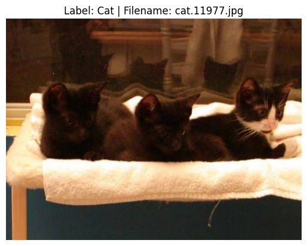

```python
IMG_INDEX = 400  # Change this index to visualize different images

# Get the image and its label
img_filename = df.loc[IMG_INDEX, 'filename']
img_label = df.loc[IMG_INDEX, 'label']
img_path = os.path.join(data_dir, img_filename)
img = Image.open(img_path)

# Display the image
plt.imshow(img)
plt.axis('off')
plt.title(f"Label: {'Dog' if img_label == 1 else 'Cat'} | Filename: {img_filename}")
plt.show()
```

### 3- Image Preprocessing – Convert Images to Numpy Arrays

```python
# Image dimension and preprocessing
IMG_SIZE = (150, 150)

def load_and_resize_image(filepath):
    img = Image.open(filepath).convert('RGB')
    img = img.resize(IMG_SIZE)
    return np.array(img)

# Load and preprocess images
X = np.array([load_and_resize_image(os.path.join(data_dir, fname)) for fname in df['filename']])
y = df['label'].values

print(f"Processed images shape: {X.shape}")
print(f"Labels shape: {y.shape}")
```

```
Processed images shape: (5000, 150, 150, 3)
Labels shape: (5000,)
```

### 4. Flattened Image and Label Overview

```python
print("Shape of X:", X.shape)   #(5000, 150, 150, 3)
print("Data type of X:", X.dtype)
print("Flattened pixel values of X[0]:")
print(X[0].flatten()[:100])

# Print the shape and data type of y
print("Shape of y:", y.shape)
print("Data type of y:", y.dtype)
print("First 20 labels in y:")
print(y[:20])
```

```
Shape of X: (5000, 150, 150, 3)
Data type of X: uint8
Flattened pixel values of X[0]:
[ 93  98  94  91  96  92  90  95  91  87  92  88  87  93  88  85  93  88
  83  92  87  83  92  87  83  92  87  83  92  88  83  93  90  84  93  90
  83  92  89  85  94  91  86  93  90  87  93  91  88  94  92  85  91  89
  85  91  89  85  89  88  84  87  86  83  86  85  79  83  82  77  79  78
  77  77  76  73  72  70  70  69  64  74  74  67 115 116 106 122 127 112
 122 128 114 122 131 118 119 130 120 120]
Shape of y: (5000,)
Data type of y: int64
First 20 labels in y:
[1 0 1 0 0 0 0 0 0 1 0 1 0 1 1 0 0 1 0 0]
```

### 5. Train-Test Split

```python
# Split the dataset into training and validation sets
X_train, X_val, y_train, y_val = train_test_split(X, y, test_size=0.2, stratify=y, random_state=42)
X_train = X_train / 255.0
X_val = X_val / 255.0

print(f"Training samples: {len(X_train)}, Validation samples: {len(X_val)}")
```

```
Training samples: 4000, Validation samples: 1000
```

### 6. Build and Train Vanilla CNN ( Model 1)

```python
cnn_model = models.Sequential([
    layers.Conv2D(32, (3, 3), activation='relu', input_shape=(150, 150, 3)),
    layers.MaxPooling2D(2, 2),
    layers.Conv2D(64, (3, 3), activation='relu'),
    layers.MaxPooling2D(2, 2),
    layers.Conv2D(128, (3, 3), activation='relu'),
    layers.MaxPooling2D(2, 2),
    layers.Flatten(),
    layers.Dense(128, activation='relu'),
    layers.Dropout(0.5),
    layers.Dense(1, activation='sigmoid')
])

# Compile the model
cnn_model.compile(loss='binary_crossentropy', optimizer='adam', metrics=['accuracy'])

# Callbacks for saving the best model and early stopping
cnn_checkpoint = ModelCheckpoint(
    "model/best_cnn_model.h5",  #  Save in HDF5 format inside 'model' folder
    save_best_only=True,
    monitor='val_loss',
    mode='min'
)


# Early stopping to prevent overfitting
cnn_early_stop = EarlyStopping(
    monitor='val_loss',
    patience=3,
    restore_best_weights=True)

# Train the CNN model
history = cnn_model.fit(
    X_train, y_train,
    epochs=10,
    batch_size=32,
    validation_data=(X_val, y_val),
    callbacks=[cnn_checkpoint, cnn_early_stop]
)
# ####
# The Training will stop early if the validation loss does not improve for 3 consecutive epochs.
# #####
```

```
e:\AI Courses\ML -Framework\Practical Lab 3\.venv\Lib\site-packages\keras\src\layers\convolutional\base_conv.py:113: UserWarning: Do not pass an `input_shape`/`input_dim` argument to a layer. When using Sequential models, prefer using an `Input(shape)` object as the first layer in the model instead.
  super().__init__(activity_regularizer=activity_regularizer, **kwargs)
```

```
125/125 ━━━━━━━━━━━━━━━━━━━━ 0s 509ms/step - accuracy: 0.5411 - loss: 0.6934
```

```
WARNING:absl:You are saving your model as an HDF5 file via `model.save()` or `keras.saving.save_model(model)`. This file format is considered legacy. We recommend using instead the native Keras format, e.g. `model.save('my_model.keras')` or `keras.saving.save_model(model, 'my_model.keras')`.
```

```
125/125 ━━━━━━━━━━━━━━━━━━━━ 76s 564ms/step - accuracy: 0.5414 - loss: 0.6933 - val_accuracy: 0.6410 - val_loss: 0.6368
125/125 ━━━━━━━━━━━━━━━━━━━━ 0s 514ms/step - accuracy: 0.6463 - loss: 0.6232
```

```
WARNING:absl:You are saving your model as an HDF5 file via `model.save()` or `keras.saving.save_model(model)`. This file format is considered legacy. We recommend using instead the native Keras format, e.g. `model.save('my_model.keras')` or `keras.saving.save_model(model, 'my_model.keras')`.
```

```
125/125 ━━━━━━━━━━━━━━━━━━━━ 79s 545ms/step - accuracy: 0.6464 - loss: 0.6232 - val_accuracy: 0.6820 - val_loss: 0.6040
125/125 ━━━━━━━━━━━━━━━━━━━━ 0s 487ms/step - accuracy: 0.7141 - loss: 0.5649
```

```
WARNING:absl:You are saving your model as an HDF5 file via `model.save()` or `keras.saving.save_model(model)`. This file format is considered legacy. We recommend using instead the native Keras format, e.g. `model.save('my_model.keras')` or `keras.saving.save_model(model, 'my_model.keras')`.
```

```
125/125 ━━━━━━━━━━━━━━━━━━━━ 65s 518ms/step - accuracy: 0.7141 - loss: 0.5648 - val_accuracy: 0.7100 - val_loss: 0.5444
125/125 ━━━━━━━━━━━━━━━━━━━━ 0s 483ms/step - accuracy: 0.7615 - loss: 0.4984
```

```
WARNING:absl:You are saving your model as an HDF5 file via `model.save()` or `keras.saving.save_model(model)`. This file format is considered legacy. We recommend using instead the native Keras format, e.g. `model.save('my_model.keras')` or `keras.saving.save_model(model, 'my_model.keras')`.
```

```
125/125 ━━━━━━━━━━━━━━━━━━━━ 64s 515ms/step - accuracy: 0.7614 - loss: 0.4984 - val_accuracy: 0.7250 - val_loss: 0.5249
125/125 ━━━━━━━━━━━━━━━━━━━━ 0s 475ms/step - accuracy: 0.7894 - loss: 0.4474
```

```
WARNING:absl:You are saving your model as an HDF5 file via `model.save()` or `keras.saving.save_model(model)`. This file format is considered legacy. We recommend using instead the native Keras format, e.g. `model.save('my_model.keras')` or `keras.saving.save_model(model, 'my_model.keras')`.
```

```
125/125 ━━━━━━━━━━━━━━━━━━━━ 64s 508ms/step - accuracy: 0.7894 - loss: 0.4473 - val_accuracy: 0.7400 - val_loss: 0.5034
125/125 ━━━━━━━━━━━━━━━━━━━━ 0s 497ms/step - accuracy: 0.8392 - loss: 0.3652
```

```
WARNING:absl:You are saving your model as an HDF5 file via `model.save()` or `keras.saving.save_model(model)`. This file format is considered legacy. We recommend using instead the native Keras format, e.g. `model.save('my_model.keras')` or `keras.saving.save_model(model, 'my_model.keras')`.
```

```
125/125 ━━━━━━━━━━━━━━━━━━━━ 66s 529ms/step - accuracy: 0.8392 - loss: 0.3653 - val_accuracy: 0.7770 - val_loss: 0.4815
125/125 ━━━━━━━━━━━━━━━━━━━━ 64s 512ms/step - accuracy: 0.8815 - loss: 0.2858 - val_accuracy: 0.7730 - val_loss: 0.4941
125/125 ━━━━━━━━━━━━━━━━━━━━ 63s 504ms/step - accuracy: 0.8987 - loss: 0.2511 - val_accuracy: 0.7770 - val_loss: 0.5062
125/125 ━━━━━━━━━━━━━━━━━━━━ 84s 522ms/step - accuracy: 0.9447 - loss: 0.1451 - val_accuracy: 0.7840 - val_loss: 0.5341
```

### 7. Visualize CNN Training

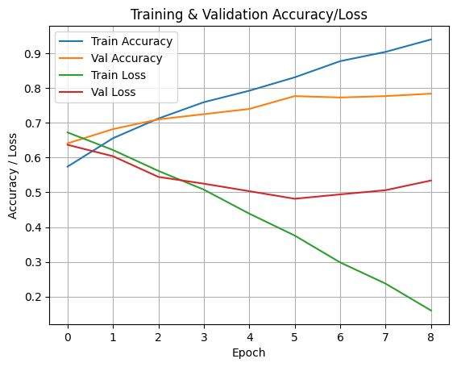

```python
plt.plot(history.history['accuracy'], label='Train Accuracy')
plt.plot(history.history['val_accuracy'], label='Val Accuracy')
plt.plot(history.history['loss'], label='Train Loss')
plt.plot(history.history['val_loss'], label='Val Loss')
plt.title("Training & Validation Accuracy/Loss")
plt.xlabel('Epoch')
plt.ylabel('Accuracy / Loss')
plt.legend()
plt.grid(True)
plt.show()
```

Evaluate Model with Confusion Matrix and Classification Report

```python
# Predict on validation set
y_pred = cnn_model.predict(X_val)
y_pred_labels = (y_pred > 0.5).astype(int)

print("Confusion Matrix:")
print(confusion_matrix(y_val, y_pred_labels))

print("\nClassification Report:")
print(classification_report(y_val, y_pred_labels, target_names=['Cat', 'Dog']))
```

```
32/32 ━━━━━━━━━━━━━━━━━━━━ 4s 115ms/step
Confusion Matrix:
[[418  82]
 [141 359]]

Classification Report:
              precision    recall  f1-score   support

         Cat       0.75      0.84      0.79       500
         Dog       0.81      0.72      0.76       500

    accuracy                           0.78      1000
   macro avg       0.78      0.78      0.78      1000
weighted avg       0.78      0.78      0.78      1000
```

### 8. Evaluate CNN Model

```python
y_pred = cnn_model.predict(X_val)
y_pred_labels = (y_pred > 0.5).astype(int)

print("Confusion Matrix:")
print(confusion_matrix(y_val, y_pred_labels))

print("\nClassification Report:")
print(classification_report(y_val, y_pred_labels, target_names=['Cat', 'Dog']))
```

```
32/32 ━━━━━━━━━━━━━━━━━━━━ 3s 104ms/step
Confusion Matrix:
[[418  82]
 [141 359]]

Classification Report:
              precision    recall  f1-score   support

         Cat       0.75      0.84      0.79       500
         Dog       0.81      0.72      0.76       500

    accuracy                           0.78      1000
   macro avg       0.78      0.78      0.78      1000
weighted avg       0.78      0.78      0.78      1000
```

### 9. Predict Single Image

```
1/1 ━━━━━━━━━━━━━━━━━━━━ 0s 66ms/step
```

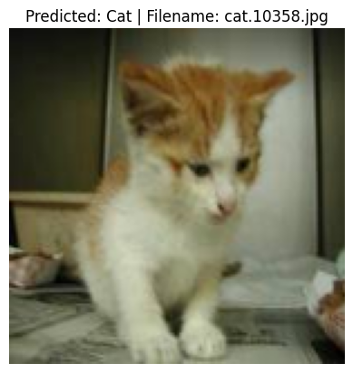

```
Predicted label for image #123: Cat (Probability: 76.774%)
Actual label: Cat
```

```python
IMG_INDEX = 123
img_filename = df.loc[IMG_INDEX, 'filename']
img_path = os.path.join(data_dir, img_filename)

img = Image.open(img_path).convert('RGB')
img = img.resize((150, 150))
img_array = np.array(img) / 255.0
img_array = np.expand_dims(img_array, axis=0)

pred = cnn_model.predict(img_array)
pred_label = 'Dog' if pred[0][0] > 0.5 else 'Cat'

plt.imshow(img)
plt.axis('off')
plt.title(f"Predicted: {pred_label} | Filename: {img_filename}")
plt.show()

print(f"Predicted label for image #{IMG_INDEX}: {pred_label} (Probability: {(1-pred[0][0])*100:.3f}%)")
print(f"Actual label: {'Dog' if df.loc[IMG_INDEX, 'label'] == 1 else 'Cat'}")
```

# Model 2 – Transfer Learning with VGG16

**Using VGG16**

### 10. Transfer Learning with VGG16

```python
X_train_vgg = preprocess_input(X_train.copy() * 255.0)
X_val_vgg = preprocess_input(X_val.copy() * 255.0)

base_model = VGG16(weights='imagenet', include_top=False, input_shape=(150, 150, 3))
for layer in base_model.layers:
    layer.trainable = False
for layer in base_model.layers[-4:]:
    layer.trainable = True

inputs = Input(shape=(150, 150, 3))
x = base_model(inputs, training=False)
x = layers.GlobalAveragePooling2D()(x)
x = layers.Dense(128, activation='relu')(x)
x = layers.Dropout(0.5)(x)
outputs = layers.Dense(1, activation='sigmoid')(x)

fine_tune_model = models.Model(inputs, outputs)

fine_tune_model.compile(optimizer=Adam(learning_rate=1e-5), loss='binary_crossentropy', metrics=['accuracy'])

vgg_checkpoint = ModelCheckpoint(
    "model/best_vgg_model.h5",
    save_best_only=True,
    monitor='val_loss',
    mode='min')

early_stop = EarlyStopping(monitor='val_loss', patience=3, restore_best_weights=True)

history_finetune = fine_tune_model.fit(
    X_train_vgg, y_train,
    validation_data=(X_val_vgg, y_val),
    epochs=10,
    batch_size=32,
    callbacks=[early_stop, vgg_checkpoint]
)
```

```
125/125 ━━━━━━━━━━━━━━━━━━━━ 0s 5s/step - accuracy: 0.6953 - loss: 2.2431
```

```
WARNING:absl:You are saving your model as an HDF5 file via `model.save()` or `keras.saving.save_model(model)`. This file format is considered legacy. We recommend using instead the native Keras format, e.g. `model.save('my_model.keras')` or `keras.saving.save_model(model, 'my_model.keras')`.
```

```
125/125 ━━━━━━━━━━━━━━━━━━━━ 733s 6s/step - accuracy: 0.6961 - loss: 2.2341 - val_accuracy: 0.9110 - val_loss: 0.2026
125/125 ━━━━━━━━━━━━━━━━━━━━ 0s 5s/step - accuracy: 0.9062 - loss: 0.2899
```

```
WARNING:absl:You are saving your model as an HDF5 file via `model.save()` or `keras.saving.save_model(model)`. This file format is considered legacy. We recommend using instead the native Keras format, e.g. `model.save('my_model.keras')` or `keras.saving.save_model(model, 'my_model.keras')`.
```

```
125/125 ━━━━━━━━━━━━━━━━━━━━ 719s 6s/step - accuracy: 0.9063 - loss: 0.2896 - val_accuracy: 0.9390 - val_loss: 0.1470
125/125 ━━━━━━━━━━━━━━━━━━━━ 0s 5s/step - accuracy: 0.9316 - loss: 0.1912
```

```
WARNING:absl:You are saving your model as an HDF5 file via `model.save()` or `keras.saving.save_model(model)`. This file format is considered legacy. We recommend using instead the native Keras format, e.g. `model.save('my_model.keras')` or `keras.saving.save_model(model, 'my_model.keras')`.
```

```
125/125 ━━━━━━━━━━━━━━━━━━━━ 686s 5s/step - accuracy: 0.9317 - loss: 0.1910 - val_accuracy: 0.9420 - val_loss: 0.1271
125/125 ━━━━━━━━━━━━━━━━━━━━ 0s 5s/step - accuracy: 0.9580 - loss: 0.1015
```

```
WARNING:absl:You are saving your model as an HDF5 file via `model.save()` or `keras.saving.save_model(model)`. This file format is considered legacy. We recommend using instead the native Keras format, e.g. `model.save('my_model.keras')` or `keras.saving.save_model(model, 'my_model.keras')`.
```

```
125/125 ━━━━━━━━━━━━━━━━━━━━ 715s 6s/step - accuracy: 0.9580 - loss: 0.1015 - val_accuracy: 0.9470 - val_loss: 0.1182
125/125 ━━━━━━━━━━━━━━━━━━━━ 0s 5s/step - accuracy: 0.9760 - loss: 0.0722
```

```
WARNING:absl:You are saving your model as an HDF5 file via `model.save()` or `keras.saving.save_model(model)`. This file format is considered legacy. We recommend using instead the native Keras format, e.g. `model.save('my_model.keras')` or `keras.saving.save_model(model, 'my_model.keras')`.
```

```
125/125 ━━━━━━━━━━━━━━━━━━━━ 714s 6s/step - accuracy: 0.9760 - loss: 0.0723 - val_accuracy: 0.9520 - val_loss: 0.1111
125/125 ━━━━━━━━━━━━━━━━━━━━ 0s 5s/step - accuracy: 0.9726 - loss: 0.0700
```

```
WARNING:absl:You are saving your model as an HDF5 file via `model.save()` or `keras.saving.save_model(model)`. This file format is considered legacy. We recommend using instead the native Keras format, e.g. `model.save('my_model.keras')` or `keras.saving.save_model(model, 'my_model.keras')`.
```

```
125/125 ━━━━━━━━━━━━━━━━━━━━ 685s 5s/step - accuracy: 0.9726 - loss: 0.0700 - val_accuracy: 0.9550 - val_loss: 0.1085
125/125 ━━━━━━━━━━━━━━━━━━━━ 0s 5s/step - accuracy: 0.9825 - loss: 0.0455
```

```
WARNING:absl:You are saving your model as an HDF5 file via `model.save()` or `keras.saving.save_model(model)`. This file format is considered legacy. We recommend using instead the native Keras format, e.g. `model.save('my_model.keras')` or `keras.saving.save_model(model, 'my_model.keras')`.
```

```
125/125 ━━━━━━━━━━━━━━━━━━━━ 751s 6s/step - accuracy: 0.9825 - loss: 0.0455 - val_accuracy: 0.9590 - val_loss: 0.1048
125/125 ━━━━━━━━━━━━━━━━━━━━ 0s 5s/step - accuracy: 0.9866 - loss: 0.0352
```

```
WARNING:absl:You are saving your model as an HDF5 file via `model.save()` or `keras.saving.save_model(model)`. This file format is considered legacy. We recommend using instead the native Keras format, e.g. `model.save('my_model.keras')` or `keras.saving.save_model(model, 'my_model.keras')`.
```

```
125/125 ━━━━━━━━━━━━━━━━━━━━ 690s 6s/step - accuracy: 0.9866 - loss: 0.0352 - val_accuracy: 0.9630 - val_loss: 0.1048
125/125 ━━━━━━━━━━━━━━━━━━━━ 0s 5s/step - accuracy: 0.9871 - loss: 0.0344
```

```
WARNING:absl:You are saving your model as an HDF5 file via `model.save()` or `keras.saving.save_model(model)`. This file format is considered legacy. We recommend using instead the native Keras format, e.g. `model.save('my_model.keras')` or `keras.saving.save_model(model, 'my_model.keras')`.
```

```
125/125 ━━━━━━━━━━━━━━━━━━━━ 708s 6s/step - accuracy: 0.9871 - loss: 0.0344 - val_accuracy: 0.9640 - val_loss: 0.0989
125/125 ━━━━━━━━━━━━━━━━━━━━ 724s 6s/step - accuracy: 0.9912 - loss: 0.0261 - val_accuracy: 0.9690 - val_loss: 0.1056
```

### 11. Visualize VGG16 Training

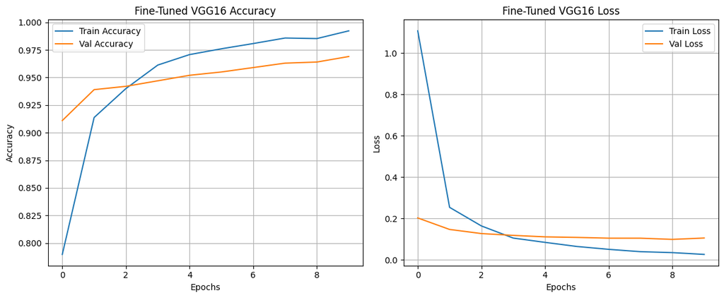

```python
plt.figure(figsize=(12, 5))

plt.subplot(1, 2, 1)
plt.plot(history_finetune.history['accuracy'], label='Train Accuracy')
plt.plot(history_finetune.history['val_accuracy'], label='Val Accuracy')
plt.title('Fine-Tuned VGG16 Accuracy')
plt.xlabel('Epochs')
plt.ylabel('Accuracy')
plt.legend()
plt.grid(True)

plt.subplot(1, 2, 2)
plt.plot(history_finetune.history['loss'], label='Train Loss')
plt.plot(history_finetune.history['val_loss'], label='Val Loss')
plt.title('Fine-Tuned VGG16 Loss')
plt.xlabel('Epochs')
plt.ylabel('Loss')
plt.legend()
plt.grid(True)

plt.tight_layout()
plt.show()
```

# Part 3 Exploring the relative performance of the models

### 1- Load Best Models and Validation Data

```python
# Load best saved models
cnn_model = load_model("model/best_cnn_model.h5")
vgg_model = load_model("model/best_vgg_model.h5")

# Predict on validation data
cnn_preds = cnn_model.predict(X_val)
vgg_preds = vgg_model.predict(X_val_vgg)

cnn_labels = (cnn_preds > 0.5).astype(int)
vgg_labels = (vgg_preds > 0.5).astype(int)
```

```
WARNING:absl:Compiled the loaded model, but the compiled metrics have yet to be built. `model.compile_metrics` will be empty until you train or evaluate the model.
WARNING:absl:Compiled the loaded model, but the compiled metrics have yet to be built. `model.compile_metrics` will be empty until you train or evaluate the model.
```

```
32/32 ━━━━━━━━━━━━━━━━━━━━ 4s 123ms/step
32/32 ━━━━━━━━━━━━━━━━━━━━ 116s 4s/step
```

### 2- Evaluate Accuracy, Confusion Matrix, and Classification Report

```python
def evaluate_model(name, y_true, y_pred, y_probs):
    print(f"### {name} Evaluation ###")
    print(f"Accuracy: {accuracy_score(y_true, y_pred):.4f}")
    print("Confusion Matrix:")
    print(confusion_matrix(y_true, y_pred))
    print("Classification Report:")
    print(classification_report(y_true, y_pred, target_names=['Cat', 'Dog']))

evaluate_model("Vanilla CNN", y_val, cnn_labels, cnn_preds)
evaluate_model("VGG16", y_val, vgg_labels, vgg_preds)
```

```
### Vanilla CNN Evaluation ###
Accuracy: 0.7770
Confusion Matrix:
[[418  82]
 [141 359]]
Classification Report:
              precision    recall  f1-score   support

         Cat       0.75      0.84      0.79       500
         Dog       0.81      0.72      0.76       500

    accuracy                           0.78      1000
   macro avg       0.78      0.78      0.78      1000
weighted avg       0.78      0.78      0.78      1000

### VGG16 Evaluation ###
Accuracy: 0.9640
Confusion Matrix:
[[480  20]
 [ 16 484]]
Classification Report:
              precision    recall  f1-score   support

         Cat       0.97      0.96      0.96       500
         Dog       0.96      0.97      0.96       500

    accuracy                           0.96      1000
   macro avg       0.96      0.96      0.96      1000
weighted avg       0.96      0.96      0.96      1000
```

### 3- Plot Precision-Recall Curve

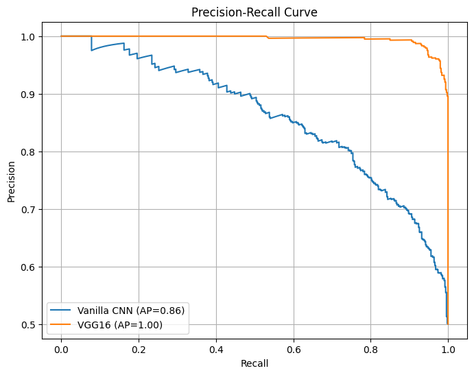

```python
def plot_pr_curve(y_true, y_probs, label):
    precision, recall, _ = precision_recall_curve(y_true, y_probs)
    avg_precision = average_precision_score(y_true, y_probs)
    plt.plot(recall, precision, label=f"{label} (AP={avg_precision:.2f})")

plt.figure(figsize=(8, 6))
plot_pr_curve(y_val, cnn_preds, "Vanilla CNN")
plot_pr_curve(y_val, vgg_preds, "VGG16")
plt.xlabel("Recall")
plt.ylabel("Precision")
plt.title("Precision-Recall Curve")
plt.legend()
plt.grid(True)
plt.show()
```

# 4- Show Misclassified Examples

```
Vanilla CNN - Total Misclassified: 223
```

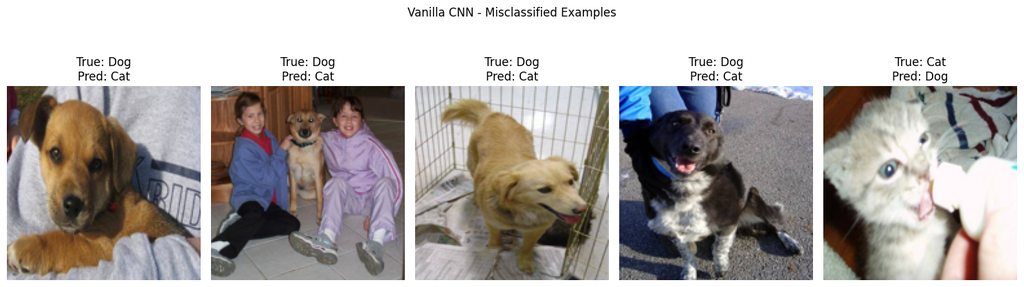

```
VGG16 - Total Misclassified: 36
```

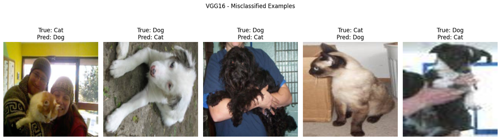

```python
def show_misclassified(X_val, y_true, y_pred, model_name):
    misclassified = np.where(y_true != y_pred.reshape(-1))[0]
    print(f"{model_name} - Total Misclassified: {len(misclassified)}")
    plt.figure(figsize=(15, 5))
    for i, idx in enumerate(misclassified[:5]):
        plt.subplot(1, 5, i + 1)
        plt.imshow(X_val[idx])
        plt.title(f"True: {'Dog' if y_true[idx] else 'Cat'}\nPred: {'Dog' if y_pred[idx] else 'Cat'}")
        plt.axis('off')
    plt.suptitle(f"{model_name} - Misclassified Examples")
    plt.tight_layout()
    plt.show()

show_misclassified(X_val, y_val, cnn_labels, "Vanilla CNN")
show_misclassified(X_val, y_val, vgg_labels, "VGG16")
```

### Conclusion

Based on the evaluation metrics, the **VGG16 model significantly outperforms the Vanilla CNN** in classifying images of cats and dogs.

#### Recommendation:

For practical deployment or further development, **VGG16 is the preferred model** due to its superior accuracy, precision, and reliability. The Vanilla CNN could be improved with techniques like data augmentation, deeper architecture, or more training data.